# Uhuru Data Set Visualization

James Waterford

2023-02-23

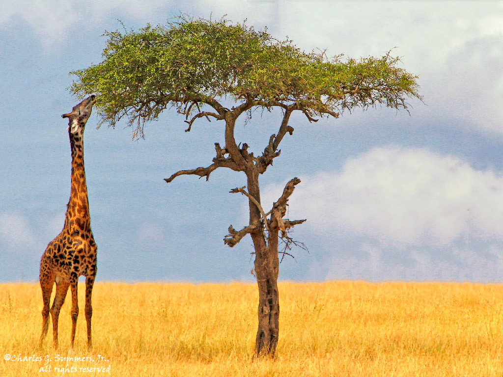

Acacia

The Working Directory inside this Rmarkdown *chunk* is listed below:

```r
getwd()
```

```
## [1] "/Users/slimjims/Desktop/master/R-studio/Bio197/197-scripts"
```

UHURU studies the effect of herbivores on the plants in Kenya.

This data set focuses on the effects of different treatments on Acacia trees. These *treaments* are different areas of Kenya, were predation levels (and species) are diversified.

We will first call the file, based on the current directory. Then we will use `read.table()` to access the file.

Using `eval = TRUE` displays the data.

```r
## Provide file using a relative path ##
acacia_csv <- ("../197-raw_storage/ACACIA_DREPANOLOBIUM_SURVEY.txt")
## add `na.strings = "dead"
acacia <- read.table(acacia_csv, header = TRUE, sep = "\t", fill = TRUE)
```

What can we quickly find out from this data set?

There are a handful of commands that can help us out. Some personal favorites are:

```r
head(acacia)
```

```
##   SURVEY YEAR  SITE BLOCK TREATMENT    PLOT   ID HEIGHT AXIS1 AXIS2 CIRC
## 1      1 2012 SOUTH     1     TOTAL S1TOTAL  581   2.25  2.75  2.15   20
## 2      1 2012 SOUTH     1     TOTAL S1TOTAL  582   2.65  4.10  3.90   28
## 3      1 2012 SOUTH     1     TOTAL S1TOTAL 3111    1.5  1.70  0.85   17
## 4      1 2012 SOUTH     1     TOTAL S1TOTAL 3112   2.01  1.80  1.60   12
## 5      1 2012 SOUTH     1     TOTAL S1TOTAL 3113   1.75  1.84  1.42   13
## 6      1 2012 SOUTH     1     TOTAL S1TOTAL 3114   1.65  1.62  0.85   15
##   FLOWERS BUDS FRUITS ANT
## 1       0    0     10  CS
## 2       0    0    150  TP
## 3       2    1     50  TP
## 4       0    0     75  CS
## 5       0    0     20  CS
## 6       0    0      0   E
```

```r
str(acacia)
```

```
## 'data.frame':    157 obs. of  15 variables:
##  $ SURVEY   : int  1 1 1 1 1 1 1 1 1 1 ...
##  $ YEAR     : int  2012 2012 2012 2012 2012 2012 2012 2012 2012 2012 ...
##  $ SITE     : chr  "SOUTH" "SOUTH" "SOUTH" "SOUTH" ...
##  $ BLOCK    : int  1 1 1 1 1 1 1 1 1 1 ...
##  $ TREATMENT: chr  "TOTAL" "TOTAL" "TOTAL" "TOTAL" ...
##  $ PLOT     : chr  "S1TOTAL" "S1TOTAL" "S1TOTAL" "S1TOTAL" ...
##  $ ID       : int  581 582 3111 3112 3113 3114 3115 3199 941 942 ...
##  $ HEIGHT   : chr  "2.25" "2.65" "1.5" "2.01" ...
##  $ AXIS1    : num  2.75 4.1 1.7 1.8 1.84 1.62 1.95 2 2.15 5.55 ...
##  $ AXIS2    : num  2.15 3.9 0.85 1.6 1.42 0.85 0.9 1.75 1.82 4.82 ...
##  $ CIRC     : num  20 28 17 12 13 15 9 12.2 13 35 ...
##  $ FLOWERS  : int  0 0 2 0 0 0 0 0 0 0 ...
##  $ BUDS     : int  0 0 1 0 0 0 0 0 0 0 ...
##  $ FRUITS   : int  10 150 50 75 20 0 0 25 0 50 ...
##  $ ANT      : chr  "CS" "TP" "TP" "CS" ...
```

```r
#summary(acacia)
```

After using the `str()` function, we see some small oddities in our data set. *Why is height a character vector?* This can be an issue for some of the mathematical calculations.

Let’s try and find where the issue lies. For Data Frames, we sort by Row, Then Column. By using `df[Row,Column]` If you run `df[,X]`, you will get the full list of values from a Column.

We can also use `$` as to sort through columns.

```r
acacia[8,2]
```

```
## [1] 2012
```

```r
##
acacia[8]
```

```
##     HEIGHT
## 1     2.25
## 2     2.65
## 3      1.5
## 4     2.01
## 5     1.75
## 6     1.65
## 7      1.2
## 8     1.45
## 9     1.87
## 10    2.38
## 11    2.58
## 12    2.65
## 13    2.35
## 14    1.88
```

[output cut: 143 more lines]

```r
##
acacia$HEIGHT
```

```
##   [1] "2.25" "2.65" "1.5"  "2.01" "1.75" "1.65" "1.2"  "1.45" "1.87" "2.38"
##  [11] "2.58" "2.65" "2.35" "1.88" "2.32" "2.39" "2.2"  "1.05" "2"    "1.28"
##  [21] "dead" "1.4"  "1.9"  "1.75" "1.8"  "2.7"  "2.02" "1.9"  "1.85" "1.65"
##  [31] "1.4"  "2.5"  "2.05" "2.26" "2.13" "1.8"  "1.85" "1.5"  "1.87" "1.58"
##  [41] "2.05" "1.75" "1.49" "1.28" "1.49" "1.07" "1.48" "1.25" "1.41" "1.6"
##  [51] "1.2"  "1.49" "1.5"  "1.65" "1.13" "1.25" "1.1"  "2.2"  "1.45" "1.6"
##  [61] "1.55" "1.5"  "1.03" "2.14" "1.2"  "1.05" "1.8"  "1.2"  "1.75" "1.45"
##  [71] "1.17" "2.15" "1.7"  "1.98" "1.26" "1.11" "1.14" "1.26" "1.3"  "1.29"
##  [81] "1.31" "1.15" "1.87" "1.47" "1.05" "2.1"  "1.99" "1.42" "1.5"  "1.06"
##  [91] "1.49" "1.8"  "1.93" "1.2"  "1.65" "1.52" "1.43" "1.25" "1.88" "1.03"
## [101] "1.1"  "1.4"  "1.05" "1.18" "1.4"  "1.37" "1.32" "1.55" "1.3"  "1.24"
## [111] "1.5"  "1.65" "2.17" "1.28" "1.07" "0.67" "0.68" "1.87" "1.35" "1.75"
## [121] "1.75" "1.64" "1.42" "dead" "0.9"  "dead" "1.8"  "2.47" "2.15" "1.7"
## [131] "1.9"  "1.95" "1.8"  "1.4"  "1"    "1.75" "1.28" "1"    "1.45" "1"
## [141] "1.03" "1.51" "1.17" "1.33" "1.3"  "1.13" "1.58" "1.06" "1.05" "1.45"
## [151] "1.15" "1.42" "1.02" "1.4"  "1.45" "1.95" "dead"
```

```r
##
```

There are values in *HEIGHT* that we cannot keep. This is stopping us from treating HEIGHT as an integer. Let’s replace those values.

```r
col_height <- as.numeric(acacia$HEIGHT)
acacia$HEIGHT <- col_height
```

By running this command, we have **coerced** the character strings into NA values. This way, we can run mathematical statistics on the daat set.

If we caught this earlier, maybe *before* we imported the data set, we could’ve forced NAs during import.

```r
acacia <- read.table(acacia_csv, header = TRUE, sep = "\t", na.strings = "dead")
```

## Can we make a graph from this data?

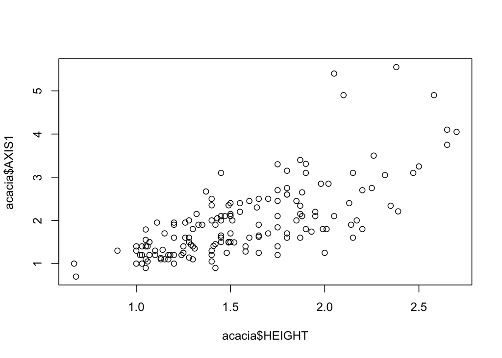

```r
plot(x=acacia$HEIGHT,y=acacia$AXIS1)
```

The `plot` function is useful, but not powerful. Its hard to add titles, and even more difficult to change plot types. How could you ever do a heatmap via plot? You can’t. So instead we use `ggplot`.

## How do we use ggplot?

That’s a goood question.

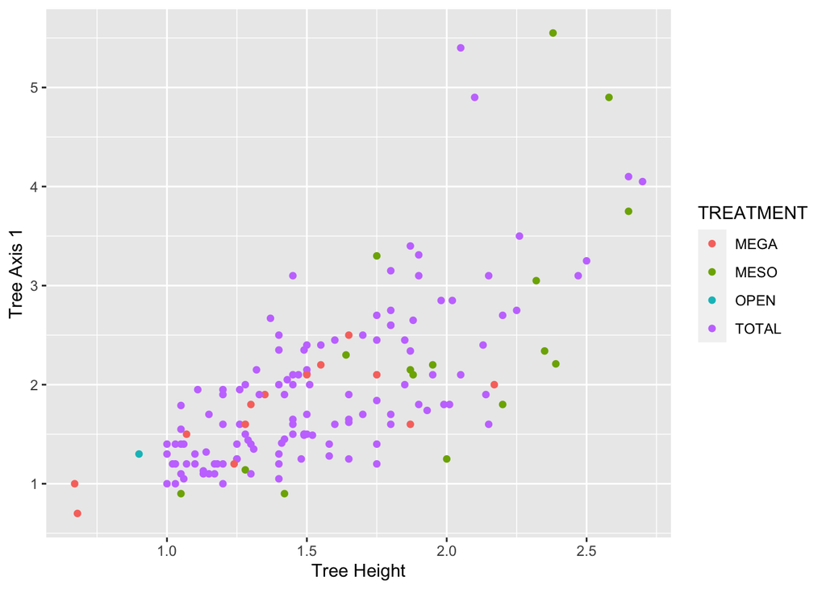

```r
library(ggplot2)
ggplot(data=acacia, mapping = aes(x=HEIGHT, y= AXIS1, color = TREATMENT)) +
  geom_point() +
  labs(x="Tree Height", y = "Tree Axis 1")
```

Use `geom_point()` to create a scatter plot.

What if we want to reshape our axes? We have functions to `scale()` the data set.

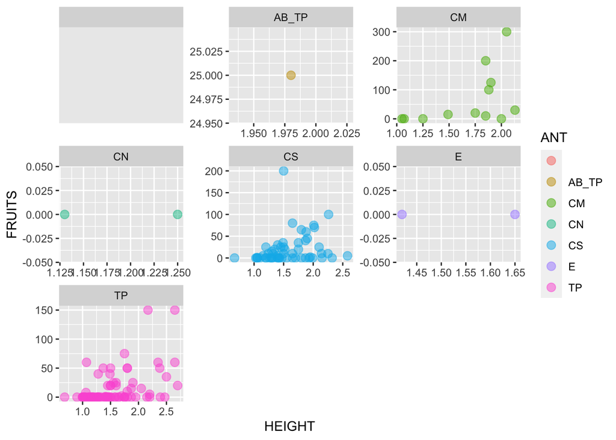

```r
ggplot(data = acacia, mapping = aes(x = HEIGHT, y = FRUITS, color = ANT)) +
  geom_point(size = 3, alpha= 0.5) +
## Use facet_wrap
  facet_wrap(~ANT, scales = "free")
```

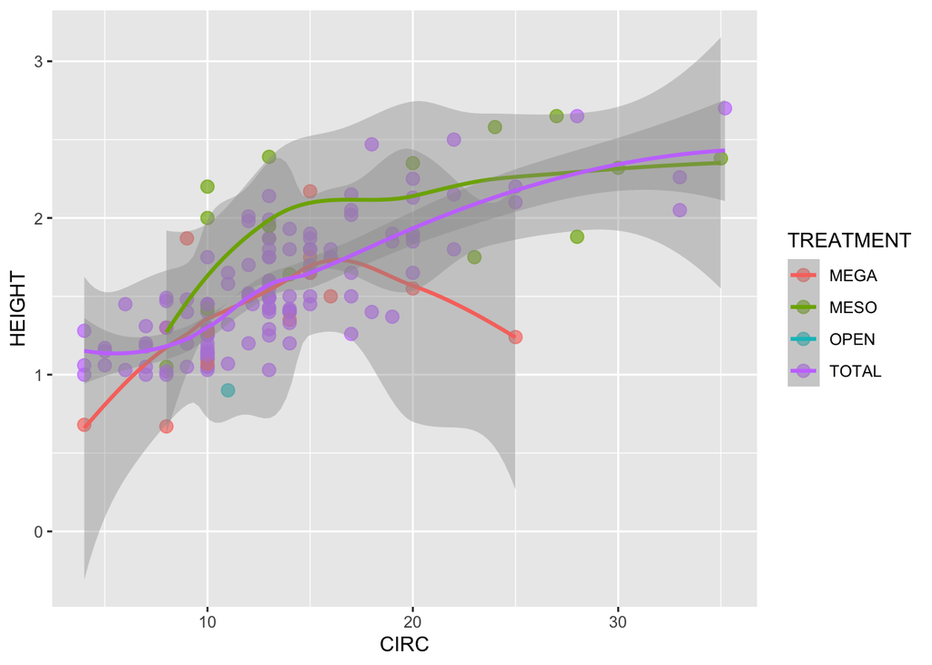

```r
##Add in geom_smooth() for data insight##

ggplot(data = acacia, mapping = aes(x = CIRC, y = HEIGHT, color = TREATMENT)) +
  ##alpha is a modifier of point transparaceny
  geom_point(size = 3, alpha = 0.667) +
  geom_smooth() #method = " +
```

```r
  ggsave(filename = "jw_acacia_treatment.jpg")
```

You must always call `ggplot` to access any of its graphical interface. The differences lie in the interlayed functions.

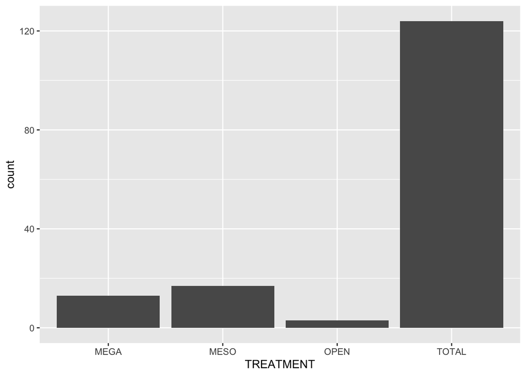

```r
ggplot(data=acacia, mapping = aes(x=TREATMENT)) +
  geom_bar()
```

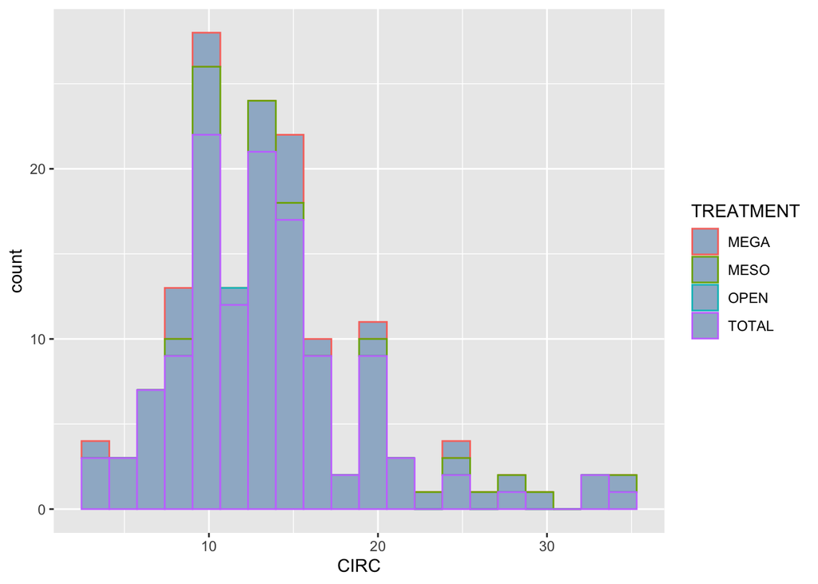

```r
ggplot(acacia, aes(x=CIRC, color= TREATMENT)) +
  ## `bins = ` defines how many boxes are displayed
  ## `Fill = ` is for color
  geom_histogram(bins = 20, fill = "slategray3")
```

```r
  #ggsave("../197-figures/acacia_Circ_by_treatment.jpg")
```